# Workflow of iClusterBayes

Here are some tests on iClusterBayes that I did but I recommend to read part 4.1 in [iClusterBayes’ article](https://academic.oup.com/biostatistics/article/19/1/71/3852318#106241193) along with iManual.pdf (access it with `iClusterPlus::iManual()` ) at page 15 that describe how the package is used.

This the standard procedure to use iClusterBayes. First, let’s import iClusterPlus and some data (Glioblastoma multiform from TCGA repository)

```r
library(iClusterPlus)
library(subtypr)
library(CancerSubtypes)
data.list <- gbm.data[c("gene.exp","methy.exp", "mirna.exp")]
data.list <- lapply(data.list, t)
```

Then check the distribution of the data:

```r
data.checkDistribution(t(data.list$gene.exp))
```

[output not shown]

```r
data.checkDistribution(t(data.list$mirna.exp))
```

[output not shown]

```r
data.checkDistribution(t(data.list$methy.exp))
```

[output not shown]

The data is normalized.

Now tune the Bayesian model, trying several possible number of k (~ number of cluster - 1). This step is very computationaly intensive.

## Basic tuning

```r
set.seed(777)
t0 <- Sys.time()
cv.fit <- tune.iClusterBayes(cpus = 7, dt1 = data.list[[1]],
                             dt2 = data.list[[2]],
                             dt3 = data.list[[3]],
                             type = c("gaussian", "gaussian","gaussian"),
                             K = 1:6,
                             n.burnin = 1000,
                             n.draw = 1200)
t_tot <- Sys.time() - t0

save(cv.fit, t_tot, file = "./tuning.RData")
```

it took 18 minutes which is fast but we’ve not set a lot of iterations so let’s see the acuracy of the results…

To choose the optimal number of cluster, we pick the value of k corresponding to the minimum BIC value

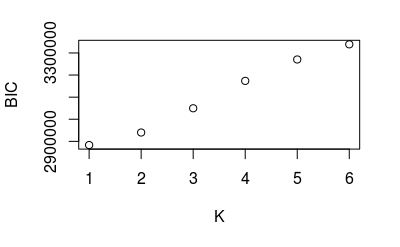

Here, the suggested number is K=1 meaning K+1 = 2 clusters…

We can also look for a plateau in the deviance ratio to find the optimal k:

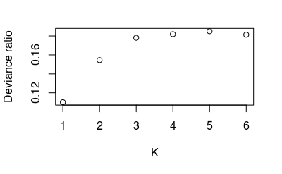

Here the plateau is reached in K=3, meaning 4 clusters as an optimal number…

In the GBM, there is 3 established sub-types

```
1   11536
```

```
No variable selected!
```

```
2   312
3   80
```

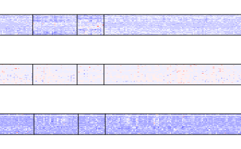

```r
iClusterPlus::plotHMBayes(cv.fit$fit[[3]], data.list, type = c("gaussian", "gaussian", "gaussian"))
```

HUm…

```
1   10846
```

```
No variable selected!
```

```
2   138
3   8
```

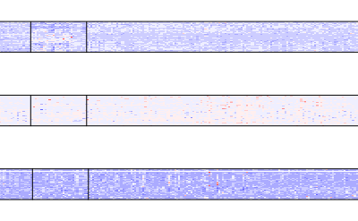

```r
iClusterPlus::plotHMBayes(cv.fit$fit[[2]], data.list, type = c("gaussian", "gaussian", "gaussian"))
```

It’s also possible to make some feature selection using lasso coefficiemnt estimates.

Let’s try with K=3.

```
1   11536
```

```
No variable selected!
```

```
2   312
3   80
```

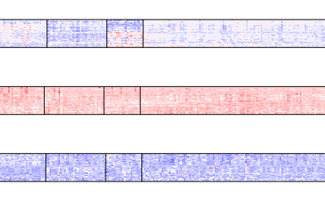

```r
iClusterPlus::plotHMBayes(cv.fit$fit[[3]], data.list.selected, type = c("gaussian", "gaussian", "gaussian"))
```

It improves the visualization of differences in mrna expression (gene.exp)

We can seek for improvements.

How to pre-process the data? How to set the parameters for the tuning of the model in `tune.iClusterBayes` ? i.e. how to set :

`n.burnin` : Number of MCMC burnin.

`n.draw`: Number of MCMC draw.

`prior.gamma`: Prior probability for the indicator variable gamma of each data set.

`sdev`: Standard deviation of random walk proposal for the latent variable.

`beta.var.scale`: A positive value to control the scale of covariance matrix of the proposed beta.

`thin`: A parameter to thin the MCMC chain in order to reduce autocorrelation. Discard all but every ’thin’th sampling values. When thin=1, all sampling values are kept.

`pp.cutoff`: Posterior probability cutoff for the indicator variable gamma. The BIC and deviance ratio will be calculated by setting parameter beta to zero when the posterior probability of gamma <= cutoff.

## Better tuning and a different dataset.